# K-means Cluster Analysis of Fishes Based on Physical Characteristics

Peerapan Nantang

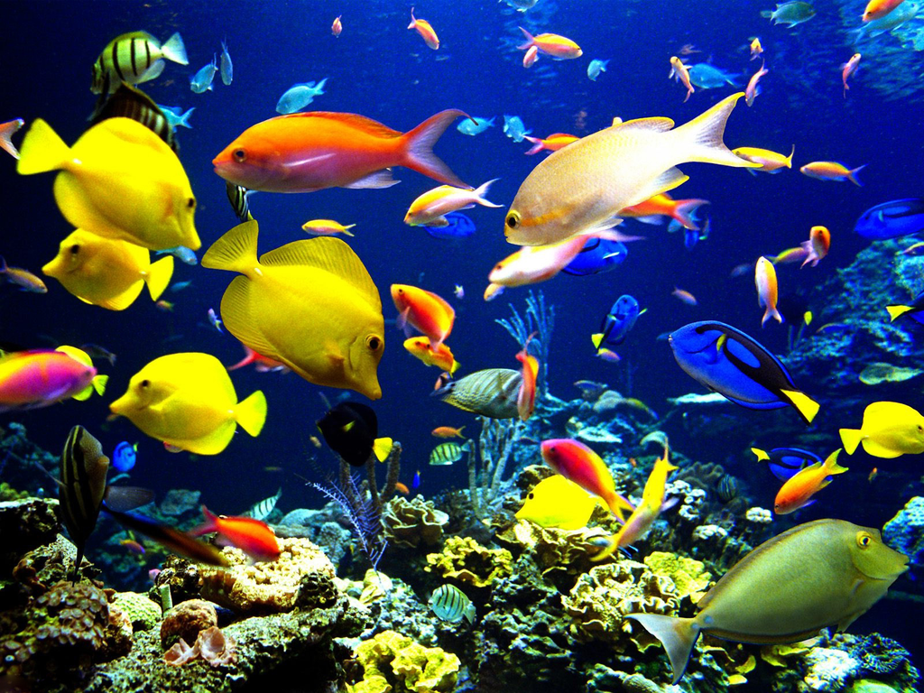

# Abstract

This report presents a cluster analysis of fishes based on their physical characteristics. A data frame containing information about 159 fish of different species is analyzed. The focus is on six physical characteristics: `Weight`, `Length1` (Vertical length), `Length2` (Diagonal length), `Length3` (Cross length), `Height`, and `Width`. All columns except the `Width` column are transformed using the square root transformation method to address their non-normality distribution. The optimal number of clusters is determined to be 3 using the Elbow method. Examination of the resulting heatmap reveals distinct patterns in the distribution of values across the different clusters. Cluster 1 consists of larger fish, Cluster 2 is made up of medium-sized fish, and Cluster 3 comprises smaller fish.

# Introduction

Fish populations exhibit a wide range of physical characteristics, and understanding these patterns can provide valuable insights into their behavior and ecology. Cluster analysis is a powerful tool for identifying patterns and relationships in datasets, and can be used to group fish based on their physical characteristics.

In this report, I will present a cluster analysis of fish data, focusing on six physical characteristics:

- `Weight`
- `Length1` (Vertical length)
- `Length2` (Diagonal length)
- `Length3` (Cross length)
- `Height`
- `Width`

The objective is to identify distinct clusters of fish based on these characteristics, and to explore the patterns and relationships within and between these clusters. The scope of this analysis is limited to the data provided, which includes information about 159 fish of different species.

## Loading Libraries for Data Analysis and Visualization

```r
library(tidyverse)
library(flextable)
library(dlookr)
library(readxl)
library(janitor)
library(factoextra)
library(cluster)
library(moments)
```

## Loading and Previewing a Data Frame

```r
df <- read_excel("Fish.xlsx")
glimpse(df)
```

```
## Rows: 159
## Columns: 7
## $ Species <chr> "Bream", "Bream", "Bream", "Bream", "Bream", "Bream", "Bream",…
## $ Weight  <dbl> 242, 290, 340, 363, 430, 450, 500, 390, 450, 500, 475, 500, 50…
## $ Length1 <dbl> 23.2, 24.0, 23.9, 26.3, 26.5, 26.8, 26.8, 27.6, 27.6, 28.5, 28…
## $ Length2 <dbl> 25.4, 26.3, 26.5, 29.0, 29.0, 29.7, 29.7, 30.0, 30.0, 30.7, 31…
## $ Length3 <dbl> 30.0, 31.2, 31.1, 33.5, 34.0, 34.7, 34.5, 35.0, 35.1, 36.2, 36…
## $ Height  <dbl> 11.5200, 12.4800, 12.3778, 12.7300, 12.4440, 13.6024, 14.1795,…
## $ Width   <dbl> 4.0200, 4.3056, 4.6961, 4.4555, 5.1340, 4.9274, 5.2785, 4.6900…
```

The `df` data frame contains information about 159 fish from different species. It has seven columns: `Species`, `Weight`, `Length1`, `Length2`, `Length3`, `Height`, and `Width`. The `Species` column is a character vector that indicates the species of fish, such as Bream, Roach, or Pike. The remaining columns are numeric vectors that provide measurements of each fish’s weight (in grams), length (in centimeters) from different points, height (in centimeters), and width (in centimeters).

Here is a brief description of each column:

- `Species`: The species name of the fish.
- `Weight`: The weight of the fish in grams.
- `Length1`: The vertical length of the fish in centimeters.
- `Length2`: The diagonal length of the fish in centimeters.
- `Length3`: The cross length of the fish in centimeters.
- `Height`: The height of the fish in centimeters.
- `Width`: The diagonal width of the fish in centimeters.

## Creating and Viewing a Subset of the Data Frame

```r
subset_df <- df[2:7] %>%
  clean_names() %>%
  glimpse()
```

```
## Rows: 159
## Columns: 6
## $ weight  <dbl> 242, 290, 340, 363, 430, 450, 500, 390, 450, 500, 475, 500, 50…
## $ length1 <dbl> 23.2, 24.0, 23.9, 26.3, 26.5, 26.8, 26.8, 27.6, 27.6, 28.5, 28…
## $ length2 <dbl> 25.4, 26.3, 26.5, 29.0, 29.0, 29.7, 29.7, 30.0, 30.0, 30.7, 31…
## $ length3 <dbl> 30.0, 31.2, 31.1, 33.5, 34.0, 34.7, 34.5, 35.0, 35.1, 36.2, 36…
## $ height  <dbl> 11.5200, 12.4800, 12.3778, 12.7300, 12.4440, 13.6024, 14.1795,…
## $ width   <dbl> 4.0200, 4.3056, 4.6961, 4.4555, 5.1340, 4.9274, 5.2785, 4.6900…
```

To focus on the relevant features for this analysis, I drop the `Species` column from the data frame and retain the remaining columns.

## Removing Duplicate Rows

```r
remove_duplicates <- function(df) {
  # Find duplicated rows
  dup_rows <- duplicated(df) | duplicated(df, fromLast = TRUE)

  # If there are no duplicated rows, return the original data frame and print "No duplicates found"
  if (!any(dup_rows)) {
    cat("No duplicates found\n")
    return(df)
  }

  # Find the row indices of the duplicated rows
  dup_indices <- which(dup_rows)

  # Group the duplicated rows by their values
  groups <- split(dup_indices, apply(df[dup_rows, ], 1, paste, collapse = ""))

  # Print a message to inform the user that duplicate rows were found
  cat("Duplicate rows found at indices:\n")

  # For each group of duplicated rows
  for (group in groups) {
    # Sort the row indices in ascending order
    group <- sort(group)

    # Print the row indices of the duplicates
    cat(paste(group, collapse = ", "), "\n")

    # Keep the row with the lowest index and remove the rest
    df <- df[!duplicated(df), ]
  }

  return(df)
}
```

```r
subset_df <- remove_duplicates(subset_df)
```

```
## No duplicates found
```

Analysis of the data frame has determined that no duplicate entries are present, indicating that each row is distinct and duplicate removal is not required.

## General Diagnosis

```r
diagnose(subset_df) %>%
  flextable()
```

| variables | types | missing_count | missing_percent | unique_count | unique_rate |
| --- | --- | --- | --- | --- | --- |
| weight | numeric | 0 | 0 | 101 | 0.6352201 |
| length1 | numeric | 0 | 0 | 116 | 0.7295597 |
| length2 | numeric | 0 | 0 | 93 | 0.5849057 |
| length3 | numeric | 0 | 0 | 124 | 0.7798742 |
| height | numeric | 0 | 0 | 154 | 0.9685535 |
| width | numeric | 0 | 0 | 152 | 0.9559748 |

Based on the results, it is observed that all variables are of numeric type and there are no missing values detected.

## General Diagnosis of Numeric Variables

```r
diagnose_numeric(subset_df) %>%
  flextable()
```

| variables | min | Q1 | mean | median | Q3 | max | zero | minus | outlier |
| --- | --- | --- | --- | --- | --- | --- | --- | --- | --- |
| weight | 0.8000 | 120.00000 | 398.331447 | 273.0000 | 650.0000 | 1,650.000 | 0 | 0 | 3 |
| length1 | 7.5000 | 19.05000 | 26.247170 | 25.2000 | 32.7000 | 59.000 | 0 | 0 | 3 |
| length2 | 8.4000 | 21.00000 | 28.415723 | 27.3000 | 35.5000 | 63.400 | 0 | 0 | 3 |
| length3 | 8.8000 | 23.15000 | 31.227044 | 29.4000 | 39.6500 | 68.000 | 0 | 0 | 1 |
| height | 1.7284 | 5.94480 | 8.970994 | 7.7860 | 12.3659 | 18.957 | 0 | 0 | 0 |
| width | 1.0476 | 3.38565 | 4.417486 | 4.2485 | 5.5845 | 8.142 | 0 | 0 | 0 |

```r
find_outliers(subset_df, index = F)
```

```
## [1] "weight"  "length1" "length2" "length3"
```

The analysis reveals the existence of outliers in `weight`, `length1`, `length2`, and `length3`.

## General Diagnosis of Outlier

```r
diagnose_outlier(subset_df) %>%
  flextable()
```

| variables | outliers_cnt | outliers_ratio | outliers_mean | with_mean | without_mean |
| --- | --- | --- | --- | --- | --- |
| weight | 3 | 1.8867925 | 1,600.00000 | 398.331447 | 375.222436 |
| length1 | 3 | 1.8867925 | 57.00000 | 26.247170 | 25.655769 |
| length2 | 3 | 1.8867925 | 61.13333 | 28.415723 | 27.786538 |
| length3 | 1 | 0.6289308 | 68.00000 | 31.227044 | 30.994304 |
| height | 0 | 0.0000000 |  | 8.970994 | 8.970994 |
| width | 0 | 0.0000000 |  | 4.417486 | 4.417486 |

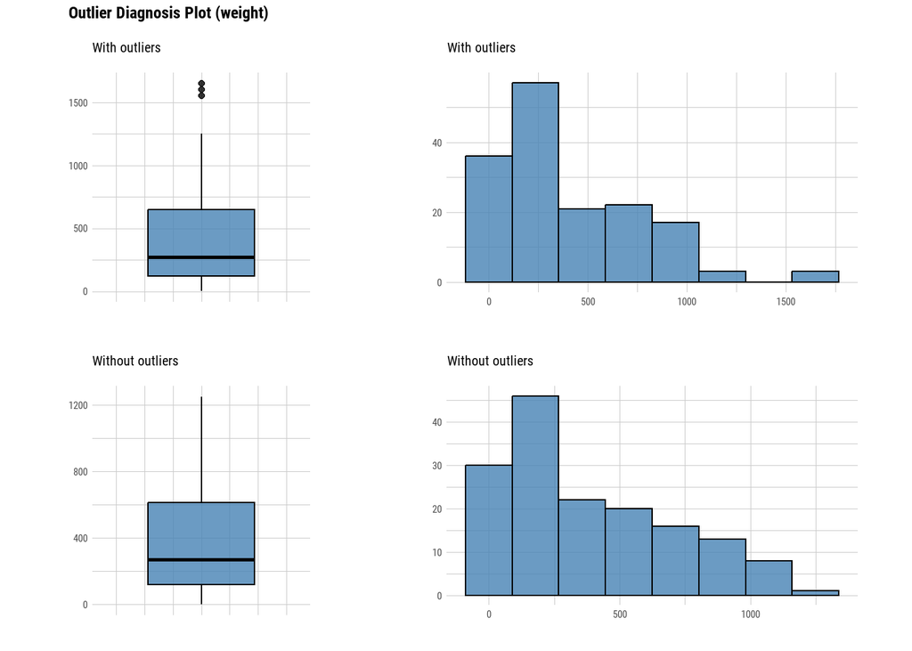

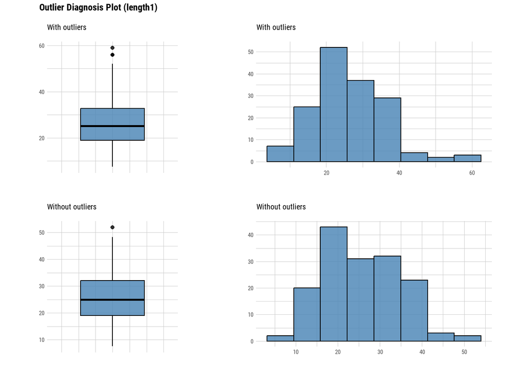

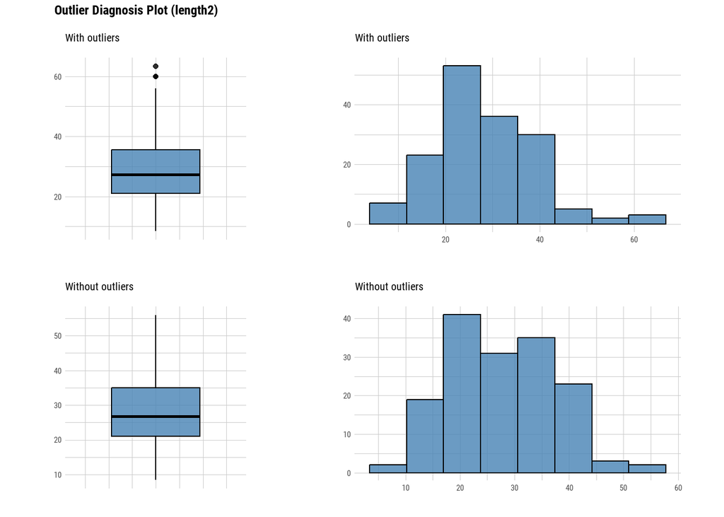

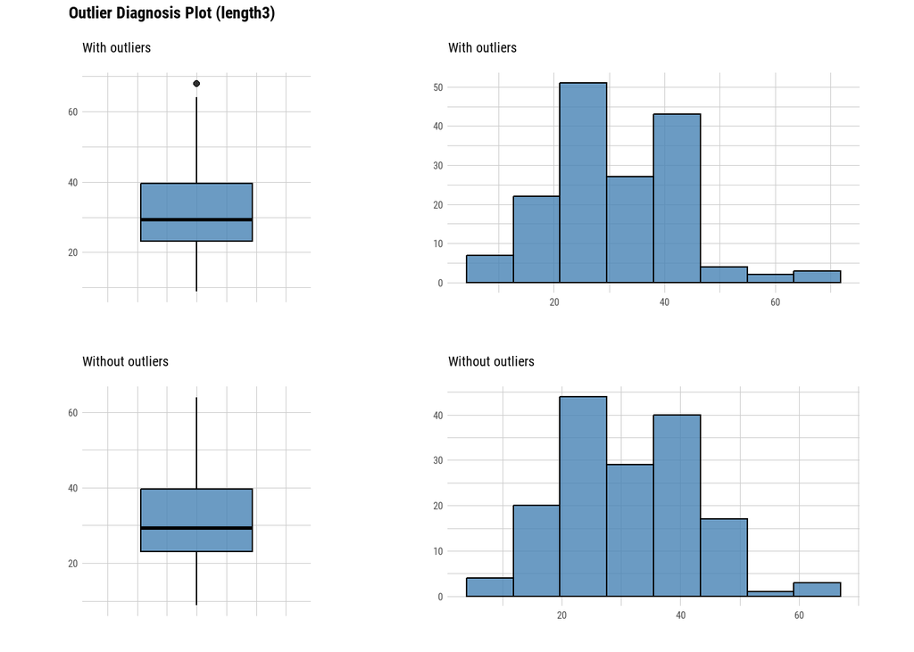

```r
subset_df %>%
  select(find_outliers(subset_df)) %>%
  plot_outlier()
```

Outlier diagnosis reveals minimal impact on the means of `length1`, `length2`, and `length3` variables, even when outliers are included. However, in the case of `weight`, outliers significantly influence the mean, indicating a need for handling these outliers.

## Imputation of Outlier

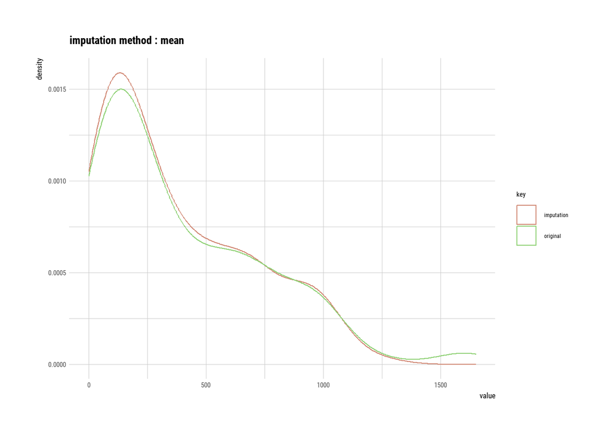

```r
imp_mean <-imputate_outlier(subset_df, weight, method = "mean")
plot(imp_mean)
```

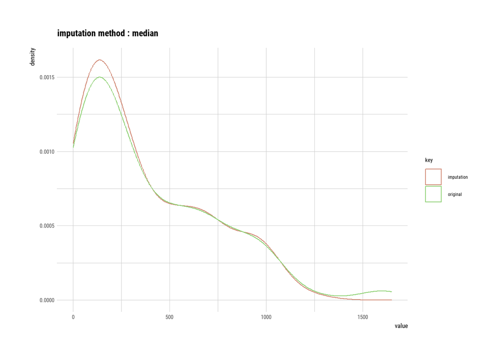

```r
imp_med <-imputate_outlier(subset_df, weight, method = "median")
plot(imp_med)
```

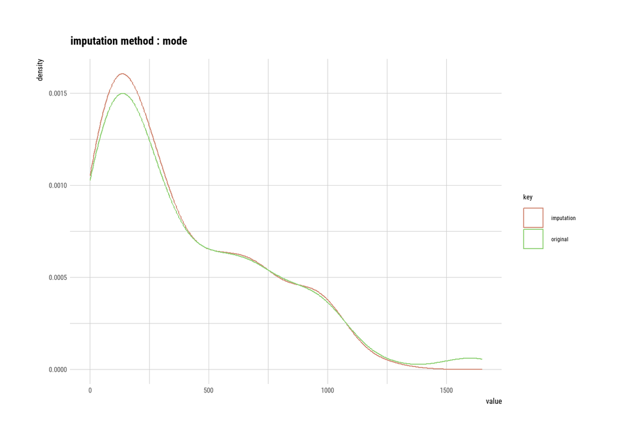

```r
imp_mode <-imputate_outlier(subset_df, weight, method = "mode")
plot(imp_mode)
```

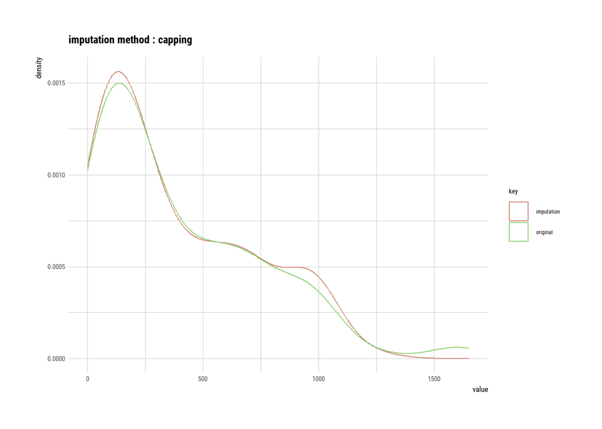

```r
imp_capp <-imputate_outlier(subset_df, weight, method = "capping")
plot(imp_capp)
```

```r
subset_df$weight <- imp_med[1:length(imp_med)]
```

Outlier imputation indicates that the median method optimally imputes outliers for the `weight` variable, as it best aligns with the original data prior to imputation.

## Outlier Diagnosis Following Outlier Imputation

```r
diagnose_outlier(subset_df) %>%
  flextable()
```

| variables | outliers_cnt | outliers_ratio | outliers_mean | with_mean | without_mean |
| --- | --- | --- | --- | --- | --- |
| weight | 0 | 0.0000000 |  | 373.293711 | 373.293711 |
| length1 | 3 | 1.8867925 | 57.00000 | 26.247170 | 25.655769 |
| length2 | 3 | 1.8867925 | 61.13333 | 28.415723 | 27.786538 |
| length3 | 1 | 0.6289308 | 68.00000 | 31.227044 | 30.994304 |
| height | 0 | 0.0000000 |  | 8.970994 | 8.970994 |
| width | 0 | 0.0000000 |  | 4.417486 | 4.417486 |

## Descriptive Statistics

```r
describe(subset_df) %>%
  flextable()
```

| described_variables | n | na | mean | sd | se_mean | IQR | skewness | kurtosis | p00 | p01 | p05 | p10 | p20 | p25 | p30 | p40 | p50 | p60 | p70 | p75 | p80 | p90 | p95 | p99 | p100 |
| --- | --- | --- | --- | --- | --- | --- | --- | --- | --- | --- | --- | --- | --- | --- | --- | --- | --- | --- | --- | --- | --- | --- | --- | --- | --- |
| weight | 159 | 0 | 373.293711 | 316.800152 | 25.1238863 | 485.00000 | 0.779898906 | -0.52836259 | 0.8000 | 6.364000 | 9.80000 | 29.58000 | 106.00000 | 120.00000 | 142.00000 | 181.60000 | 273.0000 | 344.0000 | 512.40000 | 605.0000 | 694.00000 | 900.0000 | 1,000.00000 | 1,100.000000 | 1,250.000 |
| length1 | 159 | 0 | 26.247170 | 9.996441 | 0.7927694 | 13.65000 | 0.588482331 | 0.43977392 | 7.5000 | 9.706000 | 11.30000 | 13.44000 | 18.32000 | 19.05000 | 20.00000 | 22.02000 | 25.2000 | 28.5000 | 31.62000 | 32.7000 | 34.68000 | 38.2000 | 41.19000 | 56.000000 | 59.000 |
| length2 | 159 | 0 | 28.415723 | 10.716328 | 0.8498601 | 14.50000 | 0.539863057 | 0.40375149 | 8.4000 | 10.206000 | 11.80000 | 14.62000 | 20.00000 | 21.00000 | 22.00000 | 24.00000 | 27.3000 | 31.0000 | 34.30000 | 35.5000 | 37.12000 | 41.2000 | 44.10000 | 60.000000 | 63.400 |
| length3 | 159 | 0 | 31.227044 | 11.610246 | 0.9207524 | 16.50000 | 0.391540848 | 0.07542336 | 8.8000 | 11.264000 | 13.10000 | 16.16000 | 22.20000 | 23.15000 | 23.82000 | 26.54000 | 29.4000 | 35.0000 | 38.66000 | 39.6500 | 41.12000 | 45.3400 | 46.74000 | 64.000000 | 68.000 |
| height | 159 | 0 | 8.970994 | 4.286208 | 0.3399184 | 6.42110 | 0.397186363 | -0.61417430 | 1.7284 | 1.874056 | 2.20356 | 3.76480 | 5.67150 | 5.94480 | 6.32304 | 6.97468 | 7.7860 | 9.6000 | 11.27544 | 12.3659 | 12.63040 | 15.1904 | 16.37732 | 18.685296 | 18.957 |
| width | 159 | 0 | 4.417486 | 1.685804 | 0.1336929 | 2.19885 | 0.004972246 | -0.53464479 | 1.0476 | 1.148400 | 1.28314 | 2.22784 | 3.24552 | 3.38565 | 3.55068 | 3.82704 | 4.2485 | 4.7565 | 5.24610 | 5.5845 | 6.13596 | 6.7421 | 7.28462 | 7.679758 | 8.142 |

## Normality Test

```r
normality(subset_df) %>%
  flextable()
```

| vars | statistic | p_value | sample |
| --- | --- | --- | --- |
| weight | 0.8973436 | 0.000000004363254 | 159 |
| length1 | 0.9705243 | 0.001771024022214 | 159 |
| length2 | 0.9726980 | 0.003052360113524 | 159 |
| length3 | 0.9725806 | 0.002962919161095 | 159 |
| height | 0.9608745 | 0.000185212289599 | 159 |
| width | 0.9788586 | 0.015363466327391 | 159 |

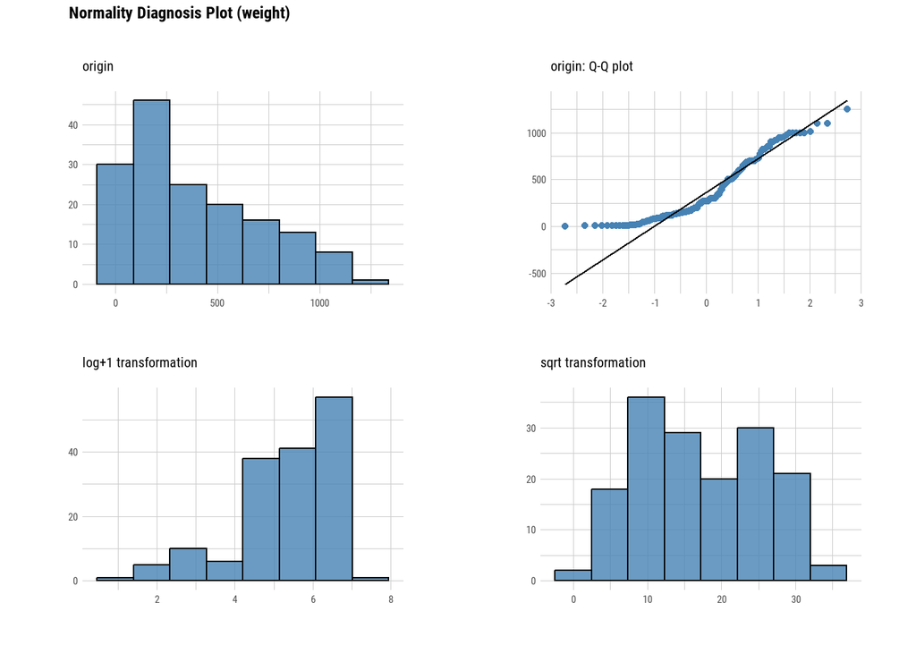

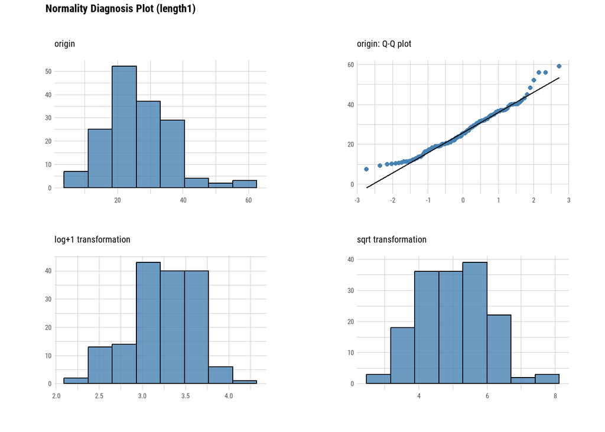

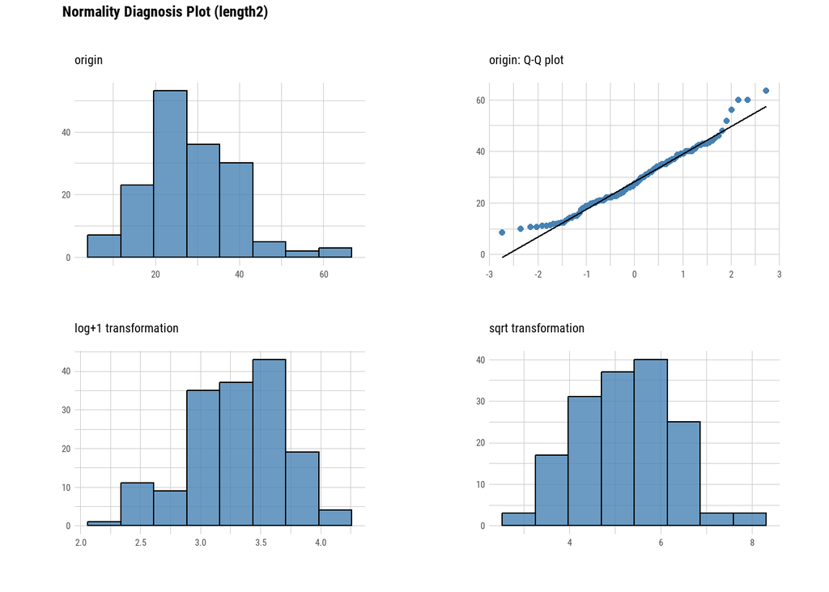

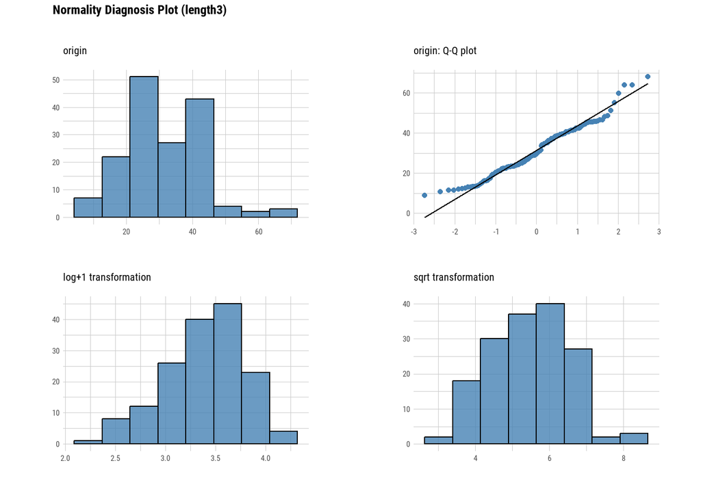

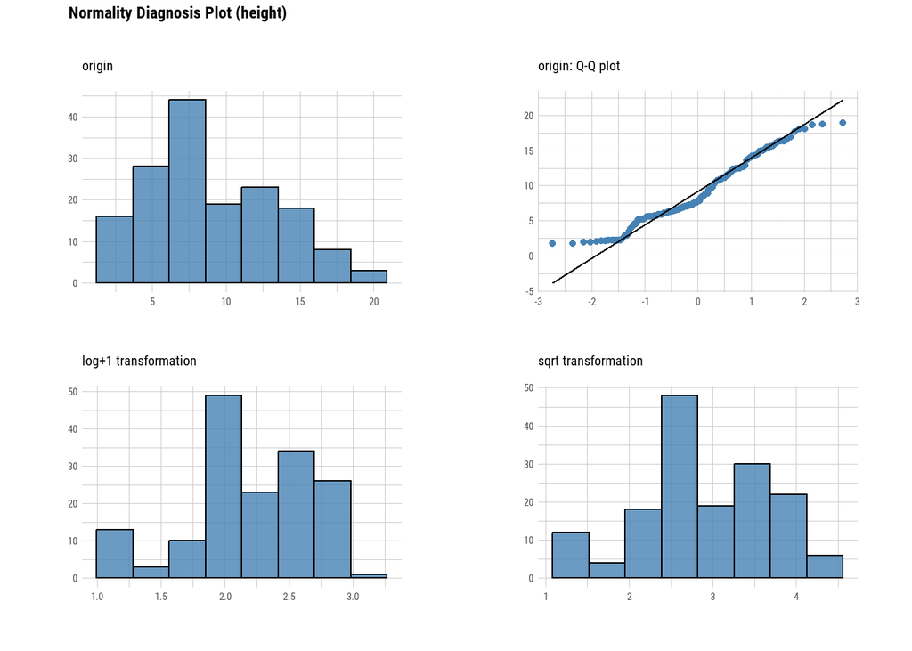

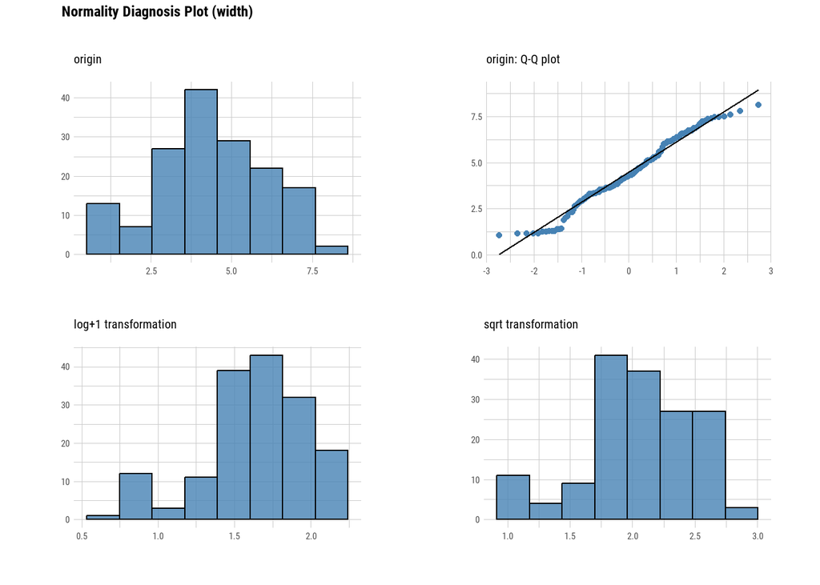

```r
subset_df %>%
  plot_normality(colnames(subset_df), left = "log+1", right = "sqrt")
```

## Skewness Test

```r
subset_df %>%
  select_if(is.numeric) %>%
  lapply(agostino.test)
```

```
## $weight
##
##  D'Agostino skewness test
##
## data:  X[[i]]
## skew = 0.77252, z = 3.73760, p-value = 0.0001858
## alternative hypothesis: data have a skewness
##
##
## $length1
##
##  D'Agostino skewness test
##
## data:  X[[i]]
## skew = 0.58292, z = 2.93344, p-value = 0.003352
## alternative hypothesis: data have a skewness
##
##
## $length2
##
##  D'Agostino skewness test
##
## data:  X[[i]]
## skew = 0.53476, z = 2.71571, p-value = 0.006613
## alternative hypothesis: data have a skewness
##
##
## $length3
##
##  D'Agostino skewness test
##
## data:  X[[i]]
## skew = 0.38784, z = 2.01864, p-value = 0.04352
## alternative hypothesis: data have a skewness
##
##
## $height
##
##  D'Agostino skewness test
##
## data:  X[[i]]
## skew = 0.39343, z = 2.04604, p-value = 0.04075
## alternative hypothesis: data have a skewness
##
##
## $width
##
##  D'Agostino skewness test
##
## data:  X[[i]]
## skew = 0.0049252, z = 0.0264343, p-value = 0.9789
## alternative hypothesis: data have a skewness
```

## Standardization and Resolving Skewness

```r
df_norm <- subset_df %>%
  mutate_at(vars(-width), ~transform(., method = "sqrt")) %>%
  mutate_all(as.numeric) %>%
  mutate_if(is.numeric, ~transform(., method = "zscore")) %>%
  mutate_all(as.numeric)


normality(df_norm) %>%
  flextable()
```

| vars | statistic | p_value | sample |
| --- | --- | --- | --- |
| weight | 0.9662556 | 0.0006323939 | 159 |
| length1 | 0.9898281 | 0.3096086140 | 159 |
| length2 | 0.9886864 | 0.2299947974 | 159 |
| length3 | 0.9819353 | 0.0356976506 | 159 |
| height | 0.9718739 | 0.0024791952 | 159 |
| width | 0.9788586 | 0.0153634663 | 159 |

## Finding the Optimal Number of Clusters

```r
plot_optimal_clusters <- function(df, kmeans, method) {
  # Check the method parameter and set the title accordingly
  if (method == "wss") {
    # If method is "wss", set title for Elbow method
    title <- "Optimal number of clusters - Elbow method"
  } else if (method == "silhouette") {
    # If method is "silhouette", set title for Silhouette method
    title <- "Optimal number of clusters - Silhouette method"
  } else {
    # If method is neither "wss" nor "silhouette", stop the function and throw an error
    stop("Invalid method")
  }

  # Use fviz_nbclust function from factoextra package to compute and visualize the optimal number of clusters
  # Add a title to the plot using ggtitle function from ggplot2 package
  fviz_nbclust(df, kmeans, method = method) +
    ggtitle(title)
}
```

In order to determine the optimal number of clusters, Elbow method, Silhouette method, and Gap Statistic with all available approaches will be used

### Elbow method

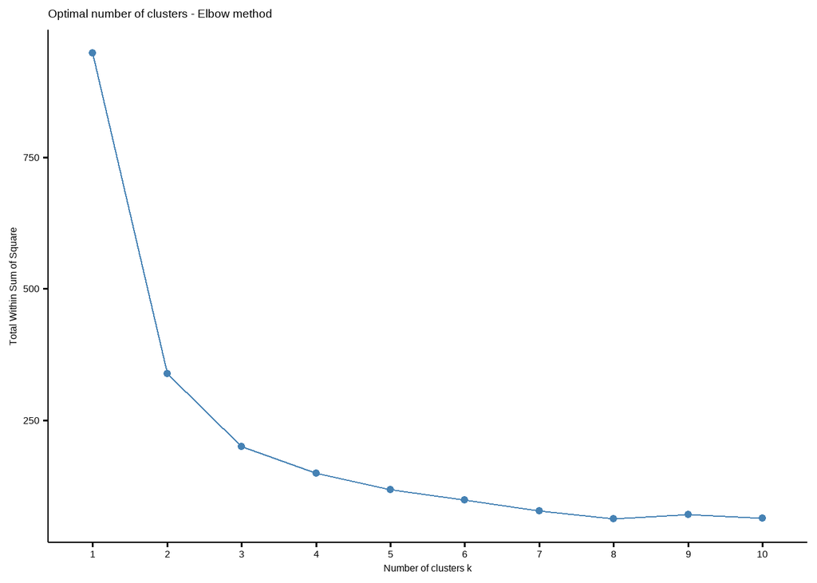

```r
plot_optimal_clusters(df_norm, kmeans, "wss")
```

Utilizing the Elbow method to determine the optimal number of clusters, it is evident that the ideal cluster count is approximately 3.

### Silhouette method

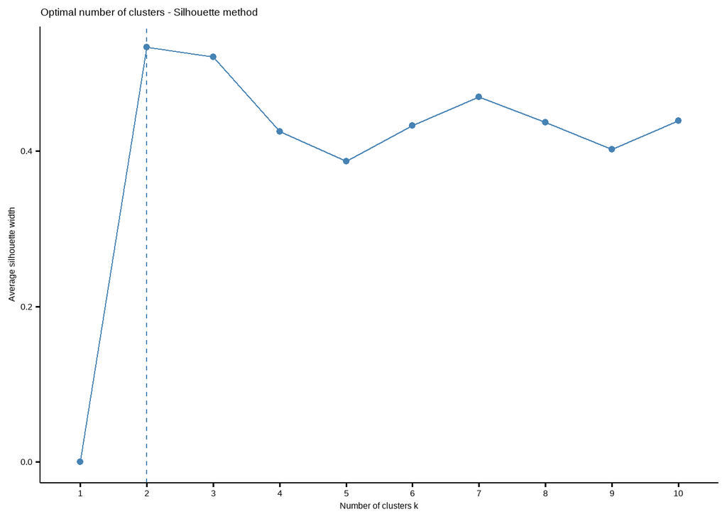

```r
plot_optimal_clusters(df_norm, kmeans, "silhouette")
```

After conducting the analysis using the Silhouette method to determine the optimal number of clusters, the finding indicates that a cluster count of 2 is ideal

### Gap statistic

```r
calculate_gap_stat <- function(df, FUN = kmeans, se_method) {
  # Set the seed for random number generation to ensure reproducibility
  set.seed(42)

  # Compute the gap statistic for a range of numbers of clusters
  # df: the data frame
  # FUN: the clustering function (default is kmeans)
  # nstart: number of random sets for initial centers
  # K.max: maximum number of clusters to consider
  # B: number of Monte Carlo ("bootstrap") samples
  gap_stat <- clusGap(df,
                      FUN = FUN,
                      nstart = 25,
                      K.max = 10,
                      B = 500)

  # Print the gap statistic
  print(gap_stat, method = se_method)

  # Plot the gap statistic against the number of clusters
  # The plot is titled with the method used to compute standard errors
  fviz_gap_stat(gap_stat, maxSE = list(method = se_method)) +
    ggtitle(paste0("Gap Statistic - ", se_method))
}
```

### Gap Statistic - firstmax

```r
calculate_gap_stat(df_norm, se_method = "firstmax")
```

```
## Clustering Gap statistic ["clusGap"] from call:
## clusGap(x = df, FUNcluster = FUN, K.max = 10, B = 500, nstart = 25)
## B=500 simulated reference sets, k = 1..10; spaceH0="scaledPCA"
##  --> Number of clusters (method 'firstmax'): 10
##           logW   E.logW       gap     SE.sim
##  [1,] 4.753814 5.012998 0.2591839 0.02743878
##  [2,] 4.247094 4.571729 0.3246344 0.02221173
##  [3,] 3.979692 4.396857 0.4171650 0.02006782
##  [4,] 3.816851 4.304199 0.4873486 0.01998184
##  [5,] 3.689914 4.228391 0.5384767 0.01970235
##  [6,] 3.566234 4.160952 0.5947187 0.01939074
##  [7,] 3.469481 4.101699 0.6322175 0.01955630
##  [8,] 3.382237 4.051124 0.6688868 0.01988601
##  [9,] 3.296149 4.007923 0.7117735 0.02018685
## [10,] 3.232578 3.970284 0.7377063 0.02017991
```

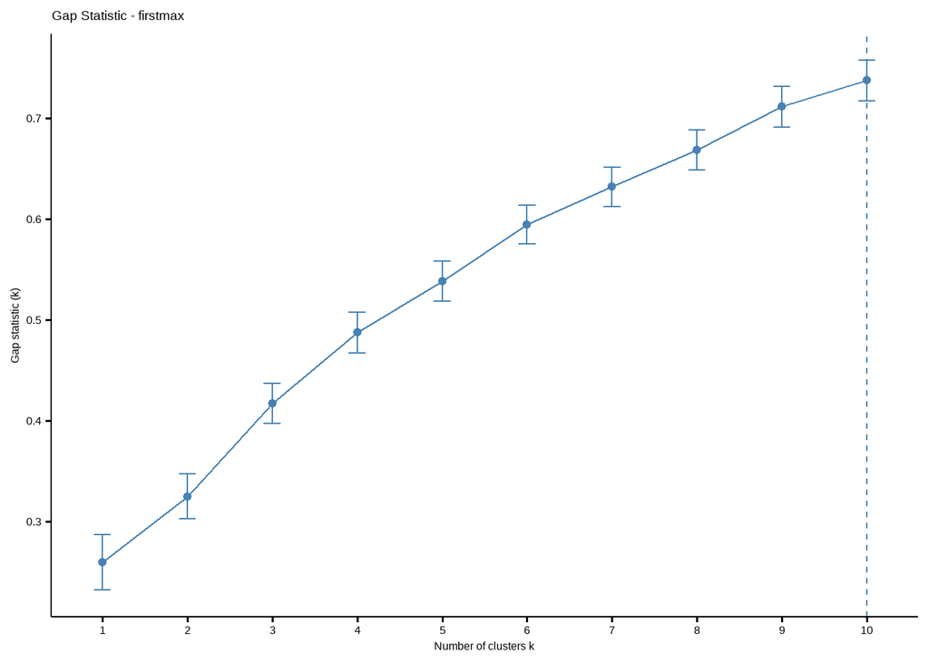

By applying the Gap Statistic method with the firstmax approach, the result shows that the optimal number of clusters is 10.

### Gap Statistic - Tibs2001SEmax

```r
calculate_gap_stat(df_norm, se_method = "Tibs2001SEmax")
```

```
## Clustering Gap statistic ["clusGap"] from call:
## clusGap(x = df, FUNcluster = FUN, K.max = 10, B = 500, nstart = 25)
## B=500 simulated reference sets, k = 1..10; spaceH0="scaledPCA"
##  --> Number of clusters (method 'Tibs2001SEmax', SE.factor=1): 10
##           logW   E.logW       gap     SE.sim
##  [1,] 4.753814 5.012998 0.2591839 0.02743878
##  [2,] 4.247094 4.571729 0.3246344 0.02221173
##  [3,] 3.979692 4.396857 0.4171650 0.02006782
##  [4,] 3.816851 4.304199 0.4873486 0.01998184
##  [5,] 3.689914 4.228391 0.5384767 0.01970235
##  [6,] 3.566234 4.160952 0.5947187 0.01939074
##  [7,] 3.469481 4.101699 0.6322175 0.01955630
##  [8,] 3.382237 4.051124 0.6688868 0.01988601
##  [9,] 3.296149 4.007923 0.7117735 0.02018685
## [10,] 3.232578 3.970284 0.7377063 0.02017991
```

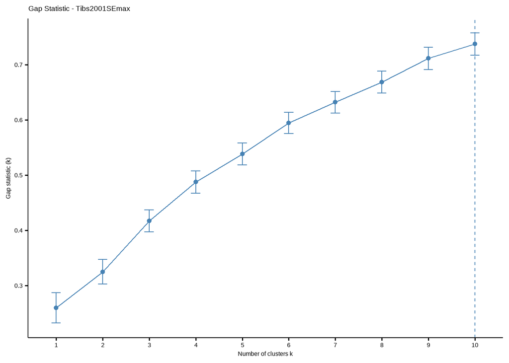

Using the Gap Statistic method with Tibs2001SEmax approach, the result determines that the optimal number of clusters is 10.

### Gap Statistic - firstSEmax

```r
calculate_gap_stat(df_norm, se_method = "firstSEmax")
```

```
## Clustering Gap statistic ["clusGap"] from call:
## clusGap(x = df, FUNcluster = FUN, K.max = 10, B = 500, nstart = 25)
## B=500 simulated reference sets, k = 1..10; spaceH0="scaledPCA"
##  --> Number of clusters (method 'firstSEmax', SE.factor=1): 10
##           logW   E.logW       gap     SE.sim
##  [1,] 4.753814 5.012998 0.2591839 0.02743878
##  [2,] 4.247094 4.571729 0.3246344 0.02221173
##  [3,] 3.979692 4.396857 0.4171650 0.02006782
##  [4,] 3.816851 4.304199 0.4873486 0.01998184
##  [5,] 3.689914 4.228391 0.5384767 0.01970235
##  [6,] 3.566234 4.160952 0.5947187 0.01939074
##  [7,] 3.469481 4.101699 0.6322175 0.01955630
##  [8,] 3.382237 4.051124 0.6688868 0.01988601
##  [9,] 3.296149 4.007923 0.7117735 0.02018685
## [10,] 3.232578 3.970284 0.7377063 0.02017991
```

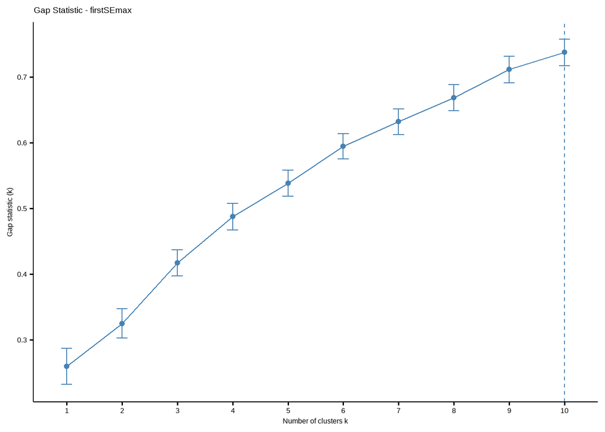

The Gap Statistic with firstSEmax method indicates 10 as the optimal cluster count.

### Gap Statistic - globalSEmax

```r
calculate_gap_stat(df_norm, se_method = "globalSEmax")
```

```
## Clustering Gap statistic ["clusGap"] from call:
## clusGap(x = df, FUNcluster = FUN, K.max = 10, B = 500, nstart = 25)
## B=500 simulated reference sets, k = 1..10; spaceH0="scaledPCA"
##  --> Number of clusters (method 'globalSEmax', SE.factor=1): 10
##           logW   E.logW       gap     SE.sim
##  [1,] 4.753814 5.012998 0.2591839 0.02743878
##  [2,] 4.247094 4.571729 0.3246344 0.02221173
##  [3,] 3.979692 4.396857 0.4171650 0.02006782
##  [4,] 3.816851 4.304199 0.4873486 0.01998184
##  [5,] 3.689914 4.228391 0.5384767 0.01970235
##  [6,] 3.566234 4.160952 0.5947187 0.01939074
##  [7,] 3.469481 4.101699 0.6322175 0.01955630
##  [8,] 3.382237 4.051124 0.6688868 0.01988601
##  [9,] 3.296149 4.007923 0.7117735 0.02018685
## [10,] 3.232578 3.970284 0.7377063 0.02017991
```

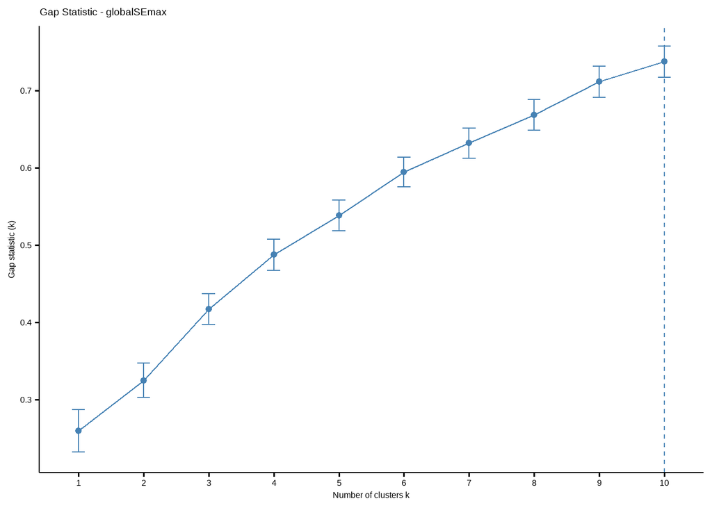

The optimal number of clusters, determined by the Gap Statistic method with the globalSEmax approach, is 10

## Determining the Optimal Number of Clusters from Different Clustering Methods

The analysis of different clustering methods indeed suggests varying optimal cluster counts for the data. The Elbow method proposes 3 clusters, while the Silhouette method recommends 2 clusters. Interestingly, the Gap Statistic method’s results are consistent across different approaches, suggesting 10 clusters. Namely, the Tibs2001SEmax, firstSEmax, globalSEmax, and firstmax approaches all indicate that 10 clusters would be optimal.

In my perspective, determining the optimal number of clusters is a balancing act between generality and detail. Choosing only 1 or 2 clusters might result in a lack of depth and limited insights. On the other hand, having as many as 10 clusters could make interpretation challenging due to the high level of detail.

Therefore, selecting 3 clusters as suggested by the Elbow method seems to strike a good balance. This choice allows for meaningful insights while preserving interpretability.

## Performing K-Means Clustering with the Optimal k

```r
set.seed(42)

km <- kmeans(x= df_norm, centers = 3, nstart = 25)
```

```r
df$cluster <- km$cluster

as_tibble(df)
```

```
## # A tibble: 159 × 8
##    Species Weight Length1 Length2 Length3 Height Width cluster
##    <chr>    <dbl>   <dbl>   <dbl>   <dbl>  <dbl> <dbl>   <int>
##  1 Bream      242    23.2    25.4    30     11.5  4.02       2
##  2 Bream      290    24      26.3    31.2   12.5  4.31       2
##  3 Bream      340    23.9    26.5    31.1   12.4  4.70       2
##  4 Bream      363    26.3    29      33.5   12.7  4.46       1
##  5 Bream      430    26.5    29      34     12.4  5.13       1
##  6 Bream      450    26.8    29.7    34.7   13.6  4.93       1
##  7 Bream      500    26.8    29.7    34.5   14.2  5.28       1
##  8 Bream      390    27.6    30      35     12.7  4.69       1
##  9 Bream      450    27.6    30      35.1   14.0  4.84       1
## 10 Bream      500    28.5    30.7    36.2   14.2  4.96       1
## # ℹ 149 more rows
```

## Visualizing the Clustering Result Using a Heatmap

```r
# Rename the columns of the dataframe 'df_norm' with the specified names
colnames(df_norm) <- c('Weight (g)',
                       'Vertical length (cm)',
                       'Diagonal length (cm)',
                       'Cross length (cm)',
                       'Height (cm)',
                       'Diagonal width (cm)')

# Add a new column 'cluster' to the dataframe 'df_norm' with the cluster assignments from 'km$cluster'
df_norm$cluster <- km$cluster

# Convert the 'cluster' column of the dataframe 'df_norm' to a factor
df_norm <- df_norm %>%
  mutate_at(vars(cluster), factor)

# Calculate the median of each column in the dataframe 'df_norm', grouped by the 'cluster' column
df_norm_median <- df_norm %>%
  group_by(cluster) %>%
  summarise_all(median)

# Reshape the dataframe 'df_norm_median' from wide format to long format, keeping 'cluster' as the id variable
df_med_long <- df_norm_median %>%
  pivot_longer(cols = -cluster, names_to = "variable", values_to = "value")
```

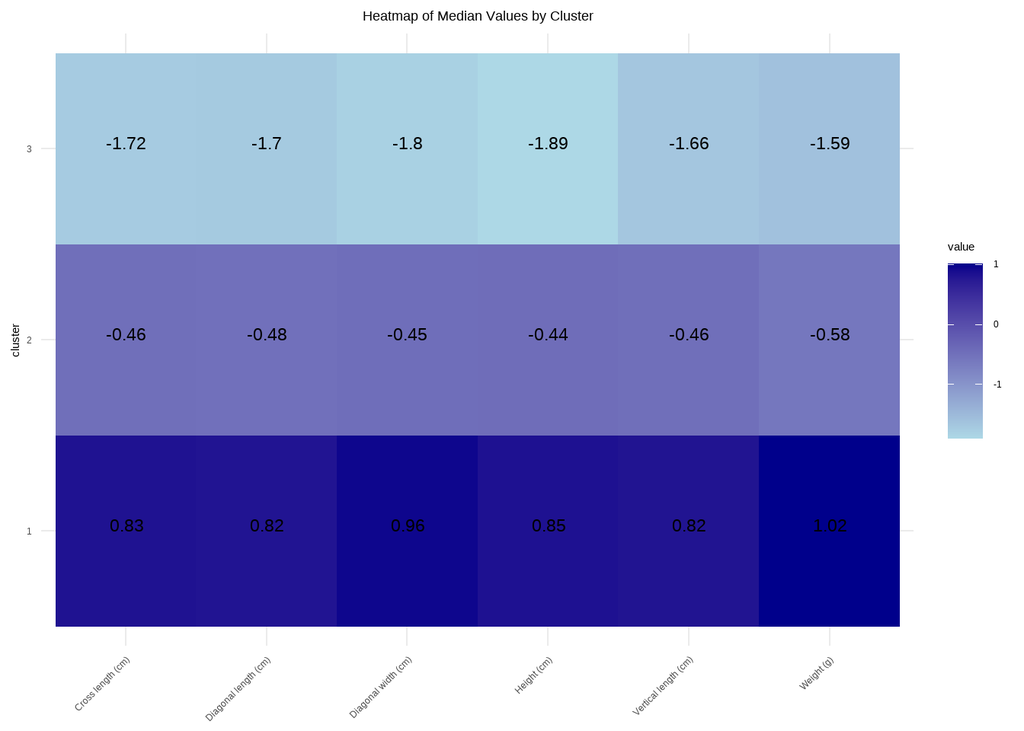

```r
# Create a ggplot object with 'df_norm_long' as the data, 'variable' as the x-axis, 'cluster' as the y-axis, and 'value' as the fill color
ggplot(df_med_long, aes(x = variable, y = cluster, fill = value)) +
  # Add a tile geom to the plot (this creates the heatmap)
  geom_tile() +
  # Define the color gradient for the fill color from light blue to dark blue
  scale_fill_gradient(low = "lightblue", high = "darkblue") +
  # Add labels to the plot (title and remove x-axis label)
  labs(title = "Heatmap of Median Values by Cluster", x = NULL) +
  # Apply a minimal theme to the plot
  theme_minimal() +
  # Add a summary statistic (median) to the plot as text, rounded to 2 decimal places
  stat_summary(fun=median,
               geom="text",
               size= 6 ,
               vjust= 0,
               aes(label = round(value, 2)),
               color = "black") +
  # Modify theme elements: rotate x-axis text by 45 degrees and center align the title
  theme(axis.text.x = element_text(angle = 45, hjust = 1),
        plot.title = element_text(hjust = 0.5))
```

Examination of the resulting heatmap reveals distinct patterns in the distribution of values across the different clusters.

Cluster 1 exhibits relatively high median values for all variables, indicating that fish assigned to this cluster are generally larger in size. Conversely, Cluster 3 displays relatively low median values for all variables, suggesting that fish assigned to this cluster are generally smaller in size. Cluster 2 exhibits intermediate median values for all variables, indicating that fish assigned to this cluster are of medium size.

# Conclusion

The analysis of the fish data reveals distinct patterns in the distribution of values across different clusters. The optimal number of clusters is determined to be 3 using the Elbow method.

- **Cluster 1** is found to contain larger fish.
- **Cluster 2** contains fish of medium size.
- **Cluster 3** contains smaller fish.

These findings provide valuable insights into the characteristics of different fish species and could be used to inform future research on fish populations. Further analysis could explore the relationship between fish size and other variables, such as habitat or diet. Additionally, the use of other clustering methods could be explored to validate the results obtained in this analysis.